[figure not shown]

# **DIAGNÓSTICO DE DOENÇAS CARDIOVASCULARES USANDO MACHINE LEARNING**

Segundo a Organização Mundial da Saúde (OMS), atualmente, mais pessoas morrem anualmente por essas enfermidades do que por qualquer outra causa. Essas doenças são de caráter sistêmico, o que implica no comprometimento de outros órgãos, em função da circulação sanguínea, como fonte de oxigênio e glicose.

Diversos fatores de risco estão associados ao desenvolvimento de DCV, os quais podem ser modificáveis ou não modificáveis. Os fatores modificáveis incluem hiperlipidemia, tabagismo, etilismo, obesidade, sedentarismo, má alimentação, etc; já os não modificáveis incluem fatores hereditários, idade, sexo e raça.

Desta forma, estima-se que cerca de 90% dessas doenças poderiam ser evitadas realizando pequenas mudanças na dieta e estilo de vida, é possível melhorar a saúde do coração e a qualidade de vida.

O que são Doenças Cardiovasculares (DCV)? As doenças do coração são alterações no funcionamento do sistema cardíaco, sendo este responsável por transportar oxigênio e nutrientes necessários às células.

De acordo com a OMS, as doenças do coração incluem

- Doença coronariana;
- Doença cerebrovasculas;
- Doença arterial periférica;
- Doença cardíaca reumática;
- Cardiopatia congênita;
- Doença reumática; entre outras.

O [Instituto Nacional de Saúde](https://medium.com/r/?url=https%3A%2F%2Fwww.sns.gov.pt%2Fwp-content%2Fuploads%2F2016%2F03%2FDoencasCardiovasculares.pdf) fornece mais detalhes sobre as DCV.

**Uso de Machine Learning na Detecção de Doenças Cardiovasculares**

Nos dias atuais, a implementação de técnicas computacionais na área da saúde tem se tornado cada vez intensa, com destaque para algoritmos de aprendizado de máquina e redes neurais artificiais. Fazendo-se uso de modelos matemáticos, é possível afirmar ou negar, a partir de conjunto de dados clínicos, o grau de influência de determinados sintomas no desenvolvimento ou aparecimento de doenças.

[figure not shown]

Existem hoje várias pesquisas na área de Machine Learning visando a construções de modelos preditivos que ajudem os médicos a descobrirem doenças cardiovasculares em seus pacientes. Estudos publicados na revista na revista Nature Biomedical Engineering mostram que algoritmos de Deep Learning foram capazes de antecipar doenças cardíacas em até 5 anos.

Recentemente, cientistas da Google, em parceria com a Verily, usaram o Machine Learning para analisar um conjunto de dados de quase 300 mil pacientes, a fim de detectar doenças cardiovasculares analisando a parte de trás dos olhos. O algoritmo conseguiu 70% de acerto ao inferir quais pacientes haviam sofrido acidentes cardiovasculares, taxa essa apenas 2% menor em comparação aos métodos tradicionais que precisam de exames de sangue.

Definitivamente, o uso de Inteligência Artificial tem impactado profundamente a área da saúde, e tem proporcionado aos profissionais médicos insumos de inteligência cada vez mais precisos.

## **Proposta deste artigo**

O presente artigo realiza análises a partir do conjunto de dados Cleveland Clinic Foundation que encontra-se disponível no Repositório UCI Machine Learning. Inicialmente, é abordada uma **análise exploratória dos dados** e, em seguida, é feita a **implementação de um modelo de Machine Learning** para prever quais pacientes, dentro do dataset, possuem doenças cardiovasculares. É fundamental ressaltar que os dados sigilosos, como nome, documentos pessoais e identidade dos pacientes foram removidos do banco de dados.

## **Obtenção do Dados**

O conjunto de dados processados contém dados de 303 pessoas e 76 atributos. Contudo, os principais artigos e estudos publicados optaram por usar apenas 14 atributos, considerados de maior relevância. Da mesma maneira, este projeto de Data Science usará essas mesmas 14 variáveis principais.

- O arquivo csv com os dados de **303 pessoas** e **14 atributos** pode ser baixado neste [link](https://medium.com/r/?url=https%3A%2F%2Fraw.githubusercontent.com%2Fcarlosfab%2Fcurso_data_science_na_pratica%2Fmaster%2Fmodulo_03%2Fheart-disease-uci.csv).
- O arquivo contendo todos os detalhes e documentação do dataset usado neste projeto se encontra neste [link](https://medium.com/r/?url=https%3A%2F%2Fgithub.com%2Fcarlosfab%2Fcurso_data_science_na_pratica%2Fblob%2Fmaster%2Fmodulo_03%2Fheart-disease.names).
- Há também um dataset disponibilizado pela [Sociedade Brasileira de Cardiologia](https://medium.com/r/?url=http%3A%2F%2Fwww.cardiometro.com.br%2Fanteriores.asp), que pode ser baixados neste [link](https://medium.com/r/?url=https%3A%2F%2Fraw.githubusercontent.com%2Fcarlosfab%2Fcurso_data_science_na_pratica%2Fmaster%2Fmodulo_03%2Fmortes_doencas_cardiovasculares.csv), que será utilizado para ver a evolução no número de mortes por doenças cardiovasculares no Brasil (entre os anos de 2004–2017).

Para realizar a análise inicial do conjunto de dados, adotaremos algumas bibliotecas geralmente utilizadas para esta finalidade:

- **Pandas** - manipulação de dados;
- **NumPy** - compatível com arranjos, vetores e matrizes de N dimensões;
- **Matplotlib** e **Seaborn** - criação de gráficos e visualização de dados;

```python
# IMPORTAÇÃO DAS BIBLIOTECAS NECESSÁRIAS PARA A ANÁLISE EXPLORATÓRIA

import pandas as pd
import numpy as np
import matplotlib.pyplot as plt
%matplotlib inline

import seaborn as sns
sns.set_style()
```

Agora, usando a biblioteca Pandas, poderemos importar e visualizar os conjuntos de dados.

Em uma etapa inicial, importaremos os dois *datasets* mencionados no início do *notebook*:

- Um contendo os dados relacionados às doenças cardiovasculares (303 pessoas e 14 atributos); e
- Um contendo os dados da mortalidade no Brasil por doenças cardiovasculares.

```python
# IMPORTAÇÃO DOS DATASETS PARA ANÁLISE

# Dataframes

df_uci = pd.read_csv("https://raw.githubusercontent.com/carlosfab/curso_data_science_na_pratica/master/modulo_03/heart-disease-uci.csv")

df_brasil = pd.read_csv("https://raw.githubusercontent.com/carlosfab/curso_data_science_na_pratica/master/modulo_03/mortes_doencas_cardiovasculares.csv")
```

```python
# VISUALIZAÇÃO DAS 5 PRIMEIRAS LINHAS DO CONJUNTO DE DADOS DA 'UCI MACHINE LEARNING'

df_uci.head()
```

|  | age | sex | cp | trestbps | chol | fbs | restecg | thalach | exang | oldpeak | slope | ca | thal | num |
| --- | --- | --- | --- | --- | --- | --- | --- | --- | --- | --- | --- | --- | --- | --- |
| 0 | 63.0 | 1.0 | 1.0 | 145.0 | 233.0 | 1.0 | 2.0 | 150.0 | 0.0 | 2.3 | 3.0 | 0.0 | 6.0 | 0 |
| 1 | 67.0 | 1.0 | 4.0 | 160.0 | 286.0 | 0.0 | 2.0 | 108.0 | 1.0 | 1.5 | 2.0 | 3.0 | 3.0 | 2 |
| 2 | 67.0 | 1.0 | 4.0 | 120.0 | 229.0 | 0.0 | 2.0 | 129.0 | 1.0 | 2.6 | 2.0 | 2.0 | 7.0 | 1 |
| 3 | 37.0 | 1.0 | 3.0 | 130.0 | 250.0 | 0.0 | 0.0 | 187.0 | 0.0 | 3.5 | 3.0 | 0.0 | 3.0 | 0 |
| 4 | 41.0 | 0.0 | 2.0 | 130.0 | 204.0 | 0.0 | 2.0 | 172.0 | 0.0 | 1.4 | 1.0 | 0.0 | 3.0 | 0 |

Antes de iniciar a análise dos dados, precisamos compreender o significado de cada variável que compõe o *dataset*. Assim, abaixo, podemos visualizar a lista com a descrição de todos os atributos.

**Informações sobre os atributos:**

- `age` - idade em anos
- `sex` - sexo do paciente
  - 0: mulher
  - 1: homem
- `cp` - tipo da dor torácica
  - 1: angina típica
  - 2: angina atípica
  - 3: dor não cardíaca
  - 4: assintomática
- `trestbps` - pressão arterial em repouso
- `chol` - colesterol sérico (*mg/dl*)
- `fbs` - açucar no sangue em jejum > 120*mg/dl*
  - 0: `False`
  - 1: `True`
- `restecg` - resultado do eletrocardiografia de repouso
  - 0: normal
  - 1: anormalidades de ST-T (inversão da onda T e elevação ou depressão de > 0.05*mV*)
  - 2: hipertrofia ventricular esquerda provável ou definitiva (pelos critérios de Romhilt-Estes)
- `thalach` - frequência cardíaca máxima atingida
- `exang` - angina induzida pelo exercício
  - 0: não
  - 1: sim
- `oldpeak` - depessão do segmento ST induzida pelo exercício em relação ao repouso
- `slope` - inclinação do segmento ST no pico do exercício
- `ca` - número de vasos principais colorido por fluoroscopia
- `thal` - *teste de esforço cardíaco*
  - 3: normal
  - 6: defeito fixo
  - 7: defeito reversível
- `num` - diagnóstico de doença cardíaca (diagnóstico angiográfico)
  - 0: não há doença cardíaca ( < 50% de estreitamento do diâmetro)
  - 1,2,3,4: há doença cardíaca ( > 50% de estreitamento do diâmetro)

Para as análises realizadas neste projeto, a principal variável de interesse será `num`, uma vez que este atributo nos fornece informações se o paciente possui ou não doenças cardiovasculares.

Observando as informações sobre os atributos, percebemos que nossa variável alvo (`num`) possui cinco valores possíveis: [0, 1, 2, 3, 4].

No entanto, seguindo a maioria das pesquisas que utilizaram esse *dataset*, iremos considerar apenas duas situações possíveis:

- **0** - não há doença cardíaca
- **1** - há doença cardíaca

Então, iremos igualar a 1 os valores compreendidos entre 1-4.

```python
# VARIÁVEL ALVO ANTES

df_uci.num.value_counts()
```

```
num
0    164
1     55
2     36
3     35
4     13
Name: count, dtype: int64
```

Agora, iremos converter os valores que são maiores ou iguais a 1 para 1.

```python
# CONVERTENDO VALORES >= 1 EM 1

df_uci.loc[df_uci.num != 0, 'num'] = 1
```

```python
# VARIÁVEL ALVO DEPOIS

df_uci.num.value_counts()
```

```
num
0    164
1    139
Name: count, dtype: int64
```

A partir dessa mudança nos valores da variável `num` podemos exporar os dados de maneira mais aprofundada.

## **Análise Exploratória**

**Qual o tamanho do *dataset* e *são* os tipos das variáveis?**

```python
# TAMANHO DO CONJUNTO DE DADOS

print('Linhas: {}'.format(df_uci.shape[0]))
print('Colunas: {}'.format(df_uci.shape[1]))
```

```
Linhas: 303
Colunas: 14
```

```python
#  TIPOS DAS VARIÁVEIS

df_uci.dtypes
```

```
age         float64
sex         float64
cp          float64
trestbps    float64
chol        float64
fbs         float64
restecg     float64
thalach     float64
exang       float64
oldpeak     float64
slope       float64
ca          float64
thal        float64
num           int64
dtype: object
```

Podemos observar que o conjunto de dados possui 303 linhas e 14 colunas e é constituído por variáveis do tipo *float* e *int*.

### **Quantos valores "não há doença cardíaca" (0) e "há doença cardíaca" (1) existem no *dataset*?**

```python
df_uci.num.value_counts()
```

```
num
0    164
1    139
Name: count, dtype: int64
```

Assim, podemos concluir que existem **139 pacientes** listados no *dataset* possuem doenças cardiovasculares, de um total de 303.

### **Do total de pacientes, quais as quantidades de homens e de mulheres?**

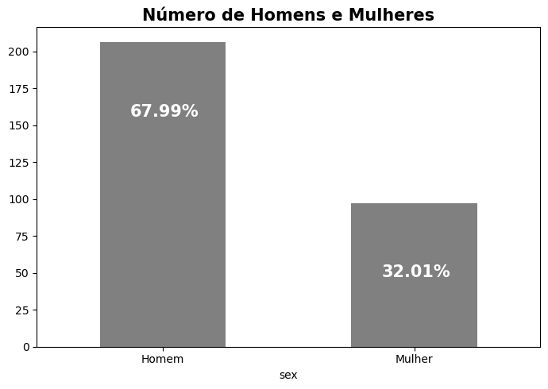

```python
fig, ax = plt.subplots(figsize = (7,5))
ax = df_uci.sex.value_counts().plot(kind = 'bar', color = 'grey')
ax.set_title('Número de Homens e Mulheres', fontsize = 15, loc ='center', weight = 'bold')
ax.set_xticklabels(['Homem' , 'Mulher'], rotation = 0)
ax.patch.set_facecolor('white')

total = []

for i in ax.patches:
    total.append(i.get_height())

soma = sum(total)

for i in ax.patches:
    ax.text(i.get_x() + .12, i.get_height() - 50,
            str(round((i.get_height()/soma)*100, 2)) + '%',
            fontsize = 15, color = 'white', weight = 'bold')

plt.tight_layout()
plt.show()
```

### **O *dataset* possui valores ausentes?**

```python
df_uci.isnull().sum()
```

```
age         0
sex         0
cp          0
trestbps    0
chol        0
fbs         0
restecg     0
thalach     0
exang       0
oldpeak     0
slope       0
ca          0
thal        0
num         0
dtype: int64
```

Podemos verificar pelas informações acima, que o *dataset* não possui valores ausentes.

### **Qual a relação entre a idade dos pacientes e o nível de colesterol?**

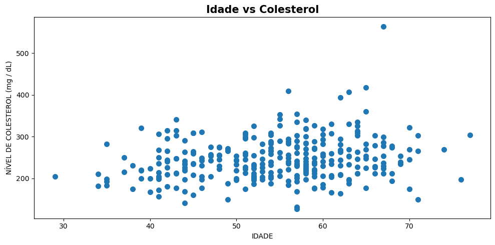

```python
fig, ax = plt.subplots(figsize = (10,5))

ax.scatter('age','chol', data = df_uci, linewidth = 2)
ax.set_title('Idade vs Colesterol', fontsize = 15, loc ='center', weight = 'bold')
ax.set_xlabel('IDADE')
ax.set_ylabel('NÍVEL DE COLESTEROL (mg / dL)')

plt.tight_layout()

plt.show()
```

Apesar de o colesterol ser essencial para os seres humanos, pois ele atua como componente de todas as membranas das nossas células, é fundamental manter o equilíbrio da sua quantidade em nosso corpo. **O nível de colesterol total recomendado é de, no máximo, 200 mg/dL**. E como sabemos, altos níveis de colesterol está relacionado a altos riscos de desenvolvimentos de doenças cardiovasculares.

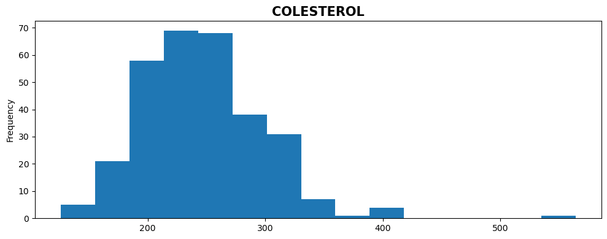

```python
fig, ax = plt.subplots(figsize=(10,4))
ax = df_uci.chol.plot.hist (bins = 15)
ax.set_title("COLESTEROL", fontsize = 15, loc = 'center', weight = 'bold')
plt.tight_layout();

plt.show()
```

O histograma é fundamental para enterdermos a distribuição de uma determinada variável dentro do conjunto de dados. Através do gráfico acima, podemos observar que a variável colesterol aparece com maior frequência para valores entre 200 e 300 mg/dL. O que significa que a maior parte dos pacientes apresentam nível de colesterol total nessa faixa, o que também pode ser facilmente observado no gráfico de dispersão.

### **Qual o grau de correlação entre as variáveis do *dataset*?**

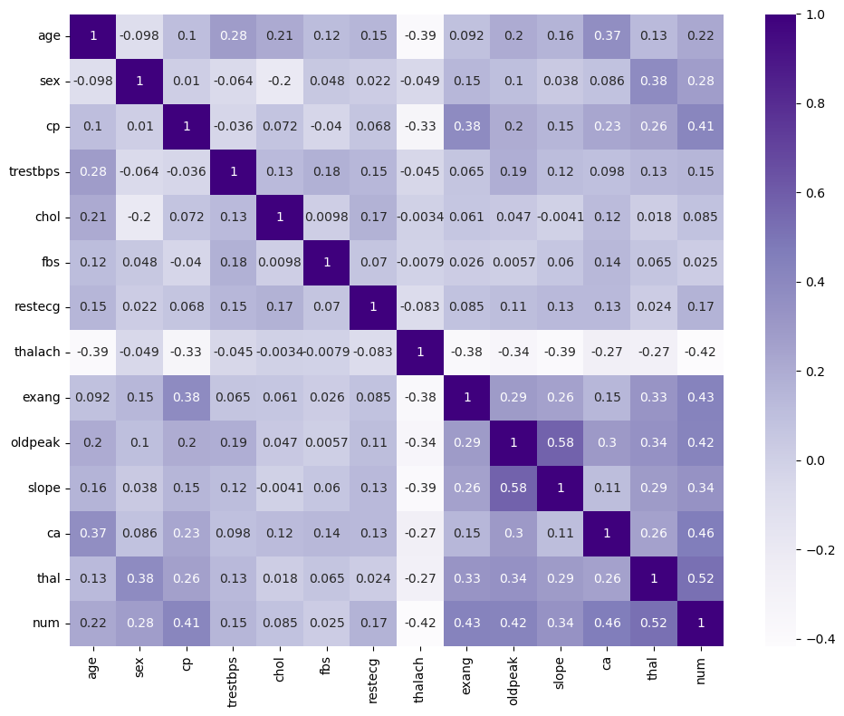

```python
fig, ax = plt.subplots(figsize = (10,8))
ax = sns.heatmap(df_uci.corr() , fmt= '.2g', cmap = 'Purples', annot= True )
plt.tight_layout()
plt.show()
```

O mapa acima basicamente nos mostra a correlação entre as variáveis, quanto maior o valor, maior é a correlação.

Assim, podemos observar que as variáveis com a maior correlação são oldpeak (depessão do segmento ST induzida pelo exercício em relação ao repouso) e slope (inclinação do segmento ST no pico do exercício), com valor de 0,58. Enquanto a menor correlação existente, - 0,42, é entre as variáveis num (diagnóstico de doença cardíaca) e thalach (frequência cardíaca máxima atingida).

## **Análises semelhantes podem ser feitas para o conjunto de dados do Brasil**

```python
# VISUALIZAÇÃO DO DATASET DF_BRASIL

df_brasil.head()
```

|  | ano | mortes_doencas_cardio |
| --- | --- | --- |
| 0 | 2017 | 383.961 |
| 1 | 2016 | 362.091 |
| 2 | 2015 | 349.584 |
| 3 | 2014 | 340.284 |
| 4 | 2013 | 339.672 |

```python
# QUAL O TAMANHO DO DATASET DF_BRASIL?

print('O dataset df_brasil possui {} linhas e {} colunas'.format(df_brasil.shape[0], df_brasil.shape[1]))
```

```
O dataset df_brasil possui 14 linhas e 2 colunas
```

```python
# QUAIS OS TIPOS DE VARIÁVEIS?

df_brasil.dtypes
```

```
ano                        int64
mortes_doencas_cardio    float64
dtype: object
```

```python
# O DATASET POSSUI VALORES AUSENTES?

df_brasil.isnull().sum()
```

```
ano                      0
mortes_doencas_cardio    0
dtype: int64
```

### **Há quantas mortes por doenças cardiovasculares no Brasil?**

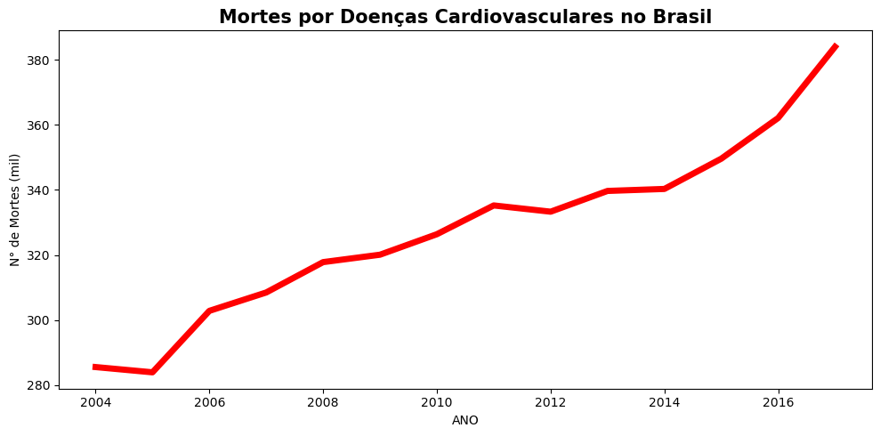

```python
fig, ax = plt.subplots(figsize = (10,5))

ax.plot('ano','mortes_doencas_cardio', data = df_brasil, linewidth = 5, markersize = 10, color = 'red')
ax.set_title('Mortes por Doenças Cardiovasculares no Brasil', fontsize = 15, loc ='center', weight = 'bold')
ax.set_xlabel('ANO')
ax.set_ylabel('N° de Mortes (mil)')

plt.tight_layout()
plt.show()
```

Como podemos observar através do gráfico acima, as análises dos dados entre os ano de 2004 e 2017 confirmam que há um aumento progressivo no número de mortes por doenças do coração no Brasil, reforçando as preocupações do Ministério da Saúde a respeito dessas doenças, com 2017 atingindo um pouco mais de 380 mil mortes.

### **Conclusões - Análise Exploratória**

Apesar de todos os esforços das organizações de saúde para reduzir o índice de doenças do coração ao redor do mundo, os números ainda são bastante preocupantes.

Entre os anos de 2004 e 2017, percebemos que o número de casos no Brasil subiu ao longo do tempo, o que reforça a importância da adoção de práticas saudáveis por parte dos brasileiros.

Também podemos entender a importância das análises de dados no processo de compreensão do comportamento das doenças cardiovasculares ao redor do mundo, permitindo a criação de estratégias para a intensificação das pesquisas sobre doenças cardiovasculares e de programas de prevenção.

Análises mais profundas, usando modelos de aprendizado de máquina, podem a partir de características dos indivíduos, calcular a probabilidade de determinados pacientes possuírem ou desenvolverem doenças cardiovasculares, inclusive auxiliando médicos em diagnósticos mais precisos.

# **Aplicação do modelo de Machine Learning**

Nesta etapa do projeto, implementaremos um modelo de Machine Learning para prever os casos em que um determinado paciente possui doença cardiovascular ou não. Assim, é necessário que o modelo de Machine Learning dê uma classificação ao ser alimentado com diversas variáveis independentes (*features*).

Para a criação do modelo de Machine Learning, utilizaremos a biblioteca **Scikit-Learn**, que possui vários algoritmos de classificação, regressão e agrupamento incluindo máquinas de vetores de suporte, florestas aleatórias, gradient boosting, k-means e DBSCAN, e é projetada para interagir com as bibliotecas Python numéricas e científicas NumPy e SciPy.

[figure not shown]

Você pode conferir os detalhes sobre o *Scikit-Learn* acessando este [link](https://scikit-learn.org/stable/).

### **Preparação dos Dados**

**Nesta etapa do projeto serão utilizados os dados do *dataset* df_uci**

Em todos os projetos de Machine Learning a etapa de pré-processamento de dados é fundamental. Aplicando as técnicas corretas para preparação dos dados, podemos aumentar consideravelmente o desempenho dos modelos implementados.

Para alimentar o modelo de Machine Learning, é necessário separar a variável alvo (dependente) do *dataset* das demais (independentes).

Geralmente, as variáveis são divididas como X e y, este projeto vai adotar o mesmo padrão.

Após separar nossas variáveis devidamente, como parte do pré-processamento dos dados, que irão alimentar o modelo de Machine Learning, será usado o **StardardScaler**, que vem junto com **sklearn.preprocessing**, para padronizar nossos dados numéricos.

```python
# DIVISÃO DOS DADOS EM TREINO E TESTE

from sklearn.model_selection import train_test_split

X_train, X_test, y_train, y_test = train_test_split(
    df_uci.drop(['num'], axis=1),   # remove as colunas label
    df_uci['num'],   # Coluna que será usada como label de classificação
    test_size=0.2,  # informamos a porcentagem de divisão para a base de testes.
    random_state=35  # aqui informamos um "seed".
)
```

```python
# IMPORTAÇÃO DAS FERRAMENTAS PARA O PRÉ-PROCESSAMENTO DOS DADOS
from sklearn.preprocessing import StandardScaler

# PADRONIZAÇÃO DOS DADOS NUMÉRICOS

# Vamos usar o StandardScaler, que padroniza os dados (média=0, desvio padrão=1).
scaler = StandardScaler()

X_train_array = scaler.fit_transform(X_train)
X_test_array = scaler.transform(X_test)

# Convertendo de volta para um DataFrame
X_train_scaler = pd.DataFrame(X_train_array, columns=X_train.columns, index=X_train.index)
X_test_scaler = pd.DataFrame(X_test_array, columns=X_test.columns, index=X_test.index)
```

Por fim, antes de implementar o modelo, iremos dividir o nosso *dataset* em dados de treino e de teste.

Essa etapa também é fundamental, uma vez que ela evita que o modelo possa fazer previsões erradas ao "viciar", em palavras simples, o modelo com um determinado conjunto de dados. Ou seja, quando nós usamos os mesmos dados para treinar e testar nossos modelos, é provável que ele não aprenda a classificar os dados, mas apenas "decorar" as respostas. Assim, ao submetir esse modelo para novos dados, ele não vai conseguir uma boa acurácia.

Por isso, é fundamental usar dados diferentes para treino e teste.

### **Modelo Random Forest**

Random Forest (floresta aleatória) é um algoritmo de aprendizagem supervisionada. Como você pode perceber pelo seu nome, ele cria uma floresta de um modo aleatório.

Segundo Niklas Donges, em um artigo do Towards Data Science, de modo simples: o algoritmo de florestas aleatórias cria várias árvores de decisão e as combina para obter uma predição com maior acurácia e mais estável.

[figure not shown]

Uma grande vantagem do algoritmo de florestas aleatórias é que ele pode ser utilizado tanto para tarefas de classificação quanto para regressão, o que representa a maioria dos sistemas de aprendizagem de máquina atuais.

Você pode conferir um artigo completo do **Towards Data Science** sobre o modelo Random Forest clicando [aqui](https://towardsdatascience.com/understanding-random-forest-58381e0602d2).

```python
# IMPORTANDO O MODELO RANDOM FOREST

from sklearn.ensemble import RandomForestClassifier
```

```python
# INSTANCIANDO O MODELO

RF_model = RandomForestClassifier(n_estimators = 10, criterion = 'entropy', random_state = 35)
```

```python
# TREINANDO O MODELO

RF_model.fit(X_train_scaler, y_train)
```

```
RandomForestClassifier(criterion='entropy', n_estimators=10, random_state=35)
```

### **Verificando o desempenho do modelo**

Uma das principais métricas utilizadas para avaliar o desempenho de um modelo de Machine Learning é a acurácia. Contudo, é importante ressaltar que cada caso é particular, com isso, uma boa acurácia nem sempre garantirá que o modelo está bom.

No caso da detecção de doenças cardiovasculares, o interesse é maximizar o número de verdadeiros positivos e minimizar o número de verdadeiros positivos e minimizar o número de falsos negativos, apesar de ser uma tarefa difícil de realizar.

Neste projeto, além da métrica de acurácia será utilizada a função classification_report para ver ver o desempenho do modelo sobre as métricas de precisão, **recall, f1-score e support**.

```python
# IMPORTAÇÃO DAS FERRAMENTAS DE MÉTRICAS

from sklearn.metrics import classification_report
from sklearn.metrics import accuracy_score
from sklearn.metrics import confusion_matrix
```

```python
# REALIZANDO A PREVISÃO NOS DADOS DE TESTE

y_pred = RF_model.predict(X_test_scaler)
```

```python
# VIZUALIZANDO A ACURÁCIA GERAL

print('[Acurácia] Random Forest:', accuracy_score(y_test, y_pred))
```

```
[Acurácia] Random Forest: 0.7377049180327869
```

```python
# VISUALIZANDO O CLASSIFICATION REPORT

print('\n[Classification Report] Random Forest')

print(classification_report(y_test, y_pred))
```

```
[Classification Report] Random Forest
              precision    recall  f1-score   support

           0       0.69      0.83      0.76        30
           1       0.80      0.65      0.71        31

    accuracy                           0.74        61
   macro avg       0.75      0.74      0.74        61
weighted avg       0.75      0.74      0.74        61
```

**Descrição das métricas**

- **Precision** - Precisão de previsões positivas..
- **Reacall** - Fração de positivos que foram identificados corretamente.
- **f1-score** - representa a média harmonica entre precision e recall, sendo 0 o pior valor e 1 o melhor.

Aparentemente, o modelo apresenta bons resultados nas métricas avaliadas. Contudo, como citado anteriormente, isso não pode garantir totalmente que o modelo seja bom.

Para complementar a nossa análise de desempenho, é interessante visualizar a **matriz de confusão**

[figure not shown]

- **VP** - Se o paciente tiver doença cardíaca e o modelo prever que possui.
- **FP** - Se o paciente não tiver doença cardíaca e o modelo prever que possui.
- **FN** - Se o paciente tiver doença cardíaca e o modelo prever que não.
- **VN** - Se o paciente não tiver doença cardíaca e o modelo prever que não.

```python
# VISUALIZANDO A MATRIZ DE CONFUSÃO

pd.DataFrame(confusion_matrix(y_test, y_pred),
             index=['neg', 'pos'], columns=['pred_neg', 'pred_pos'])
```

|  | pred_neg | pred_pos |
| --- | --- | --- |
| neg | 25 | 5 |
| pos | 11 | 20 |

A matriz de confusão funciona da seguinte maneira:

Nas linhas constam os casos reais e nas colunas, as previsões feitas pelo modelo.

### **Conclusões - Modelo de Machine Learning**

Esse exemplo de implementação de modelos de aprendizado de máquina confirma a importância do uso dessas ferramentas no diagnóstico e compreensão das doenças cardiovasculares.

É importante ressaltar que diversas outras técnicas podem ser implementadas a fim de melhorar o desempenho do modelo, a partir de melhorias no pré-processamento de dados e escolha de outros métodos de machine learning. A ampliação do conjunto de dados também é fundamental para a melhoria do modelo, uma vez que no presente projeto foi utilizado um conjunto de dados relativamente pequeno, o que dificulta a implementação do modelo.

# Atividade somativa 1

Para a atividade somativa vamos explorar o dataset **df_uci**.

# 1. Análise Exploratória

## Variáveis numéricas

Variáveis como `age`, `trestbps`, `chol` e `thalach` são numéricas. Para elas, as principais estatísticas são as de **tendência central** e as de **dispersão**.

| Estatística | O que é? | Por que é Importante na Análise? |
| --- | --- | --- |
| **Contagem (Count)** | Número total de registros não nulos. | É o primeiro passo para verificar se há **dados faltantes**. Se a contagem for menor que o total de linhas, sabemos que precisamos tratar esses dados ausentes. |
| **Média (Mean)** | A soma de todos os valores dividida pela contagem. | Dá uma noção do **valor típico** da variável. Ex: "A idade média dos pacientes na amostra é de 54 anos". A média é sensível a valores extremos (*outliers*). |
| **Mediana (Median)** | O valor do meio quando os dados estão ordenados (percentil 50%). | É uma medida de tendência central mais **robusta a outliers** que a média. Se a mediana da pressão arterial (`trestbps`) for 130 e a média for 145, isso sugere a presença de alguns pacientes com press… |
| **Desvio Padrão (Std Dev)** | Mede o grau de dispersão ou variabilidade dos dados em torno da média. | Um desvio padrão alto indica que os dados estão muito espalhados. Um desvio baixo indica que eles se concentram perto da média. Ex: Um alto desvio padrão no colesterol (`chol`) mostra uma grande diver… |
| **Mínimo (Min)** | O menor valor observado na variável. | Ajuda a entender a **amplitude** dos dados e a identificar possíveis **erros**. Ex: Se a idade mínima (`age`) fosse 0, saberíamos que há um erro de digitação ou um dado inválido. |
| **Máximo (Max)** | O maior valor observado na variável. | Assim como o mínimo, define a amplitude e ajuda a detectar **outliers**. Ex: O colesterol máximo de 564 mg/dl é um valor extremo (*outlier*) que merece investigação. |
| **Quartis (25%, 75%)** | Percentis que dividem os dados em quatro partes iguais. | - **Q1 (Percentil 25%):** 25% dos dados estão abaixo deste valor. - **Q3 (Percentil 75%):** 75% dos dados estão abaixo deste valor. Eles nos dão uma ideia da distribuição e são usados para calcular o … |

**Resumo para Variáveis Numéricas:** Uma tabela com `count`, `mean`, `std`, `min`, `25%`, `50%` (mediana), `75%`, `max` é o ponto de partida padrão para qualquer análise exploratória.

### Correlação (Entre Variáveis Numéricas)

Uma etapa adicional, mas ainda básica, é calcular a **matriz de correlação**.

- **O que é?** Mede a força e a direção da relação linear entre pares de variáveis numéricas. O valor varia de -1 a +1.
  - **+1:** Correlação positiva perfeita (quando uma sobe, a outra sobe).
  - **-1:** Correlação negativa perfeita (quando uma sobe, a outra desce).
  - **0:** Nenhuma correlação linear.
- **Por que é importante?**
  - **Entender Relações:** Ajuda a validar hipóteses. Por exemplo, poderíamos esperar uma correlação negativa entre `thalach` (frequência cardíaca máxima) e `age` (idade), já que a frequência máxima tende a diminuir com a idade.
  - **Identificar Redundância:** Variáveis com correlação muito alta (ex: > 0.9) podem ser redundantes, e talvez uma delas possa ser removida para simplificar o modelo (*feature selection*).
  - **Classes alvo**: Classes que tem alta correlação com a label a ser classificada é muito importante para o modelo de predição, já as que tem baixa correlação na maioria das vezes não são tão importantes e podem ser descartadas.

Essas estatísticas, juntas, fornecem um panorama completo e robusto do seu conjunto de dados, sendo um passo indispensável antes de qualquer visualização ou modelagem.

## Variáveis categóricas

Variáveis como `sex`, `cp`, `fbs`, `restecg`, `exang`, `slope`, `ca`, `thal` e a variável alvo `num` são categóricas. Para elas, a análise é focada na frequência.

| Estatística | O que é? | Por que é Importante na Análise? (Exemplos do seu dataset) |
| --- | --- | --- |
| **Contagem de Ocorrências (Value Counts)** | O número de vezes que cada categoria aparece. | Mostra a **distribuição das categorias**. É fundamental para entender o balanceamento do dataset. Ex: Contar os valores da coluna `sex` nos dirá quantos pacientes são homens (1) e quantos são mulheres… |
| **Frequência Relativa (Percentage)** | A proporção de cada categoria em relação ao total. | Facilita a comparação. Ex: "70% dos pacientes são do sexo masculino" é mais intuitivo do que "200 pacientes são homens". Isso é especialmente importante para a variável alvo (`num`), pois nos diz se a… |
| **Moda (Mode)** | A categoria que aparece com mais frequência. | Identifica o **grupo mais comum** na amostra. Ex: Se a moda da coluna `cp` (tipo de dor no peito) for 4 (assintomático), isso indica que a maioria dos pacientes no estudo não relatou dor no peito. |
| **Número de Categorias Únicas (Unique)** | O número de valores distintos que a variável pode assumir. | Ajuda a confirmar se a variável é realmente categórica e a entender sua complexidade (cardinalidade). Ex: A variável `sex` tem 2 valores únicos (0 e 1). A variável `cp` tem 4. |

## ProfileReport

Uma ferramenta poderosa para a análiseexploratória é o **ProfileReport** da biblioteca ydata_profiling. Esta ferramenta gera um relatório detalhado e interativo sobre um DataFrame do pandas, automatizando o processo de Análise Exploratória de Dados (AED). Dentre as principais ferramentas estão;

1. Visão Geral (Overview): Mostra estatísticas gerais do conjunto de dados, como o número de variáveis, número de observações, valores em falta (missing values), percentagem de valores em falta, linhas duplicadas e o tamanho total na memória. Também informa os tipos de variáveis detetadas (numéricas, categóricas, etc.).
2. Alertas (Alerts): Esta é uma das funcionalidades mais úteis. O relatório identifica automaticamente potenciais problemas nos dados, como colunas com alta correlação, alta cardinalidade (muitos valores únicos), assimetria (skewness) nos dados, ou colunas com um valor constante.
3. Análise de Variáveis (Variables): Para cada coluna do DataFrame, o relatório fornece estatísticas detalhadas.
   - Para variáveis numéricas: Estatísticas descritivas (média, mediana, desvio padrão, etc.), um histograma da distribuição, e valores mais comuns.
   - Para variáveis categóricas: Contagem de valores únicos, um gráfico de barras com a frequência de cada categoria.
4. Correlações (Correlations): Apresenta matrizes de correlação (como Pearson, Spearman, etc.) para visualizar a relação entre as variáveis numéricas.
5. Valores em Falta (Missing Values): Mostra visualizações como matrizes ou gráficos de barras para ajudar a entender onde os valores em falta estão localizados e em que quantidade.
6. Amostra (Sample): Exibe as primeiras e as últimas linhas do conjunto de dados, semelhante aos métodos .head() e .tail() do pandas.

```python
from ydata_profiling import ProfileReport # importando o pandas-profiling para fazer o profile do dataset

profile = ProfileReport(df_uci)
profile.to_file("relatorio_df_uci.html")
```

[output not shown]

### 2. Fatores Protetores (Correlações Negativas com `num`)

Um valor negativo significa que, quando o valor da variável aumenta, a probabilidade de ter doença cardíaca tende a *diminuir*.

### Resumo Executivo da Análise

Os indicadores mais fortes para prever a presença de doença cardíaca neste dataset são:

Por outro lado, uma **alta frequência cardíaca máxima (`thalach`)** atingida no teste de esforço é o principal indicador de ausência de doença.

Esta análise de correlação é um guia excelente para a próxima etapa: a **seleção de variáveis (*feature selection*)** para construir um modelo de Machine Learning. As variáveis com maior correlação (positiva ou negativa) com `num` são as candidatas mais promissoras.

# 2. Analisando com gráficos

## Gráficos para Análise Univariada (Entendendo Cada Variável Isoladamente)

### Box Plot (Diagrama de Caixa):

- O que mostra? Um resumo de cinco números: mínimo, primeiro quartil (Q1), mediana (Q2), terceiro quartil (Q3) e máximo.
- Por que usar? É excelente para identificar?
  - **outliers** (valores atípicos), que aparecem como pontos fora dos "bigodes" do gráfico.
  - **dispersão dos dados** (o tamanho da caixa)
  - **simetria dos dados**, quando a linha da mediana está no centro(Q2). Se a mediana esta mais para o alto (Q3), existe uma distribuição assimétrica negativa, e vice-versa.
- Exemplo: Um box plot para chol (colesterol) provavelmente mostraria aquele valor de 564 mg/dl como um outlier claro, muito acima do resto dos pacientes.

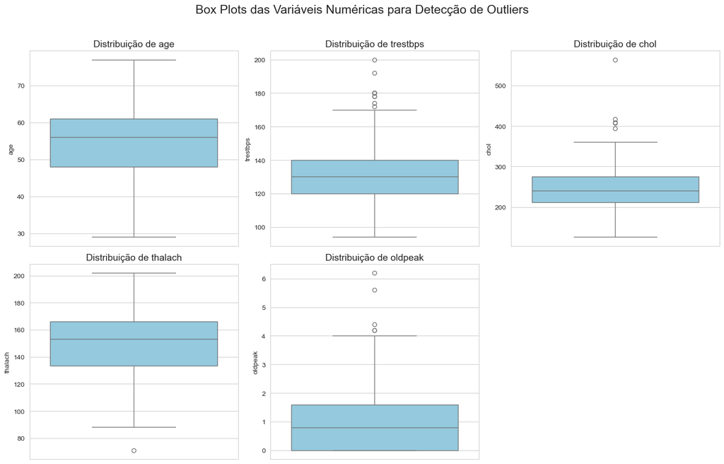

```python
from io import StringIO

# Identificar as colunas numéricas para os box plots
numeric_cols = ['age', 'trestbps', 'chol', 'thalach', 'oldpeak']

# Configurações de estilo para os gráficos
sns.set_style("whitegrid")
plt.figure(figsize=(15, 10))

# Título geral para a figura
plt.suptitle("Box Plots das Variáveis Numéricas para Detecção de Outliers", fontsize=18, y=0.95)

# Loop para criar um box plot para cada coluna numérica
for i, col in enumerate(numeric_cols):
    plt.subplot(2, 3, i + 1)  # Cria uma grade de subplots
    sns.boxplot(y=df_uci[col], color='skyblue')
    plt.title(f'Distribuição de {col}', fontsize=14)
    plt.ylabel(col)

plt.tight_layout(rect=[0, 0, 1, 0.93]) # Ajusta o layout para não sobrepor títulos
plt.show()
```

#### Análise do Gráfico de Box Plot:

trestbps (Pressão Arterial), chol (Colesterol) e oldpeak mostram claramente a presença de outliers — valores que estão significativamente acima do restante dos dados. O colesterol, em particular, tem um outlier muito extremo (acima de 500).

Essa visualização é crucial para decidir se é necessário tratar esses outliers (removê-los ou transformá-los) antes de treinar um modelo de machine learning.

## Gráficos para Análise Multivariada (Visão Geral e Relações Complexas)

### Gráfico de Dispersão com Matiz (Scatter Plot with Hue):

- O que mostra? Um gráfico de dispersão entre duas variáveis numéricas, mas onde a cor de cada ponto é definida por uma terceira variável (categórica).
- Por que usar? Permite analisar a interação de três variáveis ao mesmo tempo.
- Exemplo: O mesmo gráfico de dispersão entre oldpeak e thalach, mas agora colorindo os pontos de acordo com o diagnóstico num. Isso poderia revelar se os pacientes com frequência cardíaca máxima alta tendem a se concentrar em uma área específica do gráfico em que tenha pacientes com depressão do segmento ST baixa, que tenha doença cardíaca.

O seguinte código irá gerar um gráfico de dispersão onde cada ponto representa um paciente. O eixo X será a depressão do ST (oldpeak), o eixo Y será a frequência cardíaca máxima (thalach), e a cor do ponto indicará se o paciente tem ou não doença cardíaca.

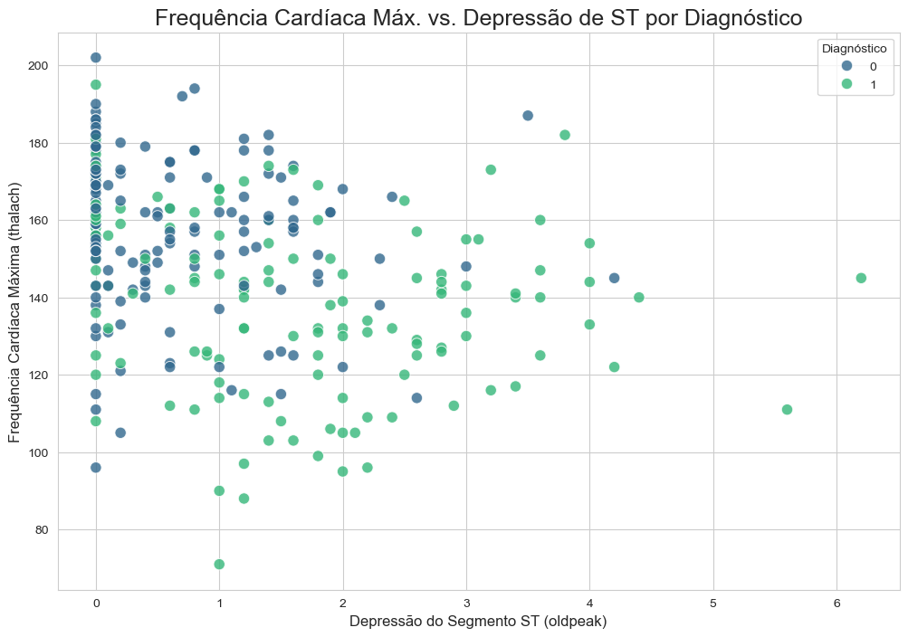

```python
# --- Geração do Gráfico ---
# Configurações de estilo
sns.set_style("whitegrid")
plt.figure(figsize=(12, 8))

# Criando o Gráfico de Dispersão com Matiz (Scatter Plot with Hue)
# x='oldpeak': Depressão do ST no eixo x
# y='thalach': Frequência cardíaca máxima no eixo y
# hue='num': A cor dos pontos é definida pelo diagnóstico
sns.scatterplot(
    data=df_uci,
    x='oldpeak',
    y='thalach',
    hue='num',
    palette='viridis', # Esquema de cores (pode ser 'coolwarm', 'magma', etc.)
    alpha=0.8, # Transparência dos pontos
    s=80 # Tamanho dos pontos
)

# Melhorando o gráfico com títulos e rótulos
plt.title('Frequência Cardíaca Máx. vs. Depressão de ST por Diagnóstico', fontsize=18)
plt.xlabel('Depressão do Segmento ST (oldpeak)', fontsize=12)
plt.ylabel('Frequência Cardíaca Máxima (thalach)', fontsize=12)
plt.legend(title='Diagnóstico')

plt.show()
```

### Análise do Gráfico Gerado

Este gráfico é extremamente revelador e mostra uma clara separação entre os dois grupos de pacientes:

1. **Pacientes "Sem Doença" (Pontos Azuis):**
   - Concentram-se predominantemente no **canto superior esquerdo** do gráfico.
   - Isso corresponde a valores **altos** de `thalach` (frequência cardíaca máxima) e valores **baixos** (próximos de zero) de `oldpeak` (depressão de ST).
   - **Interpretação Clínica:** Este é o perfil de um coração saudável. Ele consegue atingir altas frequências cardíacas durante o esforço sem mostrar sinais de isquemia (depressão de ST).
2. **Pacientes "Com Doença" (Pontos Verdes):**
   - Concentram-se predominantemente no **canto inferior direito** do gráfico.
   - Isso corresponde a valores **baixos** de `thalach` e valores **altos** de `oldpeak`.
   - **Interpretação Clínica:** Este é o perfil clássico de doença arterial coronariana. O coração não consegue atingir altas frequências (limitação funcional) e, ao mesmo tempo, apresenta sinais claros de isquemia quando submetido a esforço.

# 3. Usando modelos preditivos

1. Regressão Logística: calcula a probabilidade de um paciente pertencer à classe "doente" com base em uma combinação linear das variáveis de entrada.
2. SVM: Tenta encontrar a "linha" ou "hiperplano" que melhor separa as duas classes (pacientes doentes e não doentes) no espaço de dados, com a maior margem possível entre elas.
3. XGBoost: Também usa árvores, mas de forma sequencial. Ele constrói uma árvore, vê onde ela errou, e constrói a próxima árvore para corrigir os erros da anterior. É um processo de aprendizado iterativo e focado nos erros.

```python
from sklearn.model_selection import train_test_split
from sklearn.pipeline import Pipeline
from sklearn.feature_selection import VarianceThreshold
from sklearn.linear_model import LogisticRegression
from sklearn.svm import SVC
from sklearn.ensemble import RandomForestClassifier
from xgboost import XGBClassifier
from sklearn.metrics import accuracy_score, classification_report, confusion_matrix
```

## Variance Threshold + Scaler + Regressão Logística

Este é o nosso modelo de base: simples, rápido e interpretável.

```python
# vamos verificar qual é a variancia de cada coluna
print("\nVariância de cada coluna do dataset de treino:")
print(X_train.var())
print("-" * 30)
```

```
Variância de cada coluna do dataset de treino:
age           79.216848
sex            0.226278
cp             0.910137
trestbps     338.266537
chol        2926.034087
fbs            0.127156
restecg        0.987552
thalach      515.653458
exang          0.223603
oldpeak        1.372589
slope          0.383817
ca             0.793611
thal           3.698639
dtype: float64
------------------------------
```

```python
# Definir o pipeline
pipeline_lr = Pipeline([
    ('variance_threshold', VarianceThreshold(threshold=0.2)), # Remove features com baixa variância
    ('scaler', scaler), # Padroniza os dados
    ('logistic_regression', LogisticRegression(random_state=35, max_iter=2000)) # O modelo
])

#  Treinar o pipeline
pipeline_lr.fit(X_train, y_train)

#  Fazer previsões e avaliar
y_pred_lr = pipeline_lr.predict(X_test)
accuracy_lr = accuracy_score(y_test, y_pred_lr)

print(f"Acurácia: {accuracy_lr:.4f}")
print("\nRelatório de Classificação:")
print(classification_report(y_test, y_pred_lr, target_names=['Sem Doença', 'Com Doença']))
```

```
Acurácia: 0.7869

Relatório de Classificação:
              precision    recall  f1-score   support

  Sem Doença       0.76      0.83      0.79        30
  Com Doença       0.82      0.74      0.78        31

    accuracy                           0.79        61
   macro avg       0.79      0.79      0.79        61
weighted avg       0.79      0.79      0.79        61
```

## Variance Threshold + Scaler + SVM (Support Vector Machine)

SVM é um modelo poderoso que busca a melhor "fronteira" para separar as classes

```python
# --- Pipeline 2: SVM ---

#  Definir o pipeline
pipeline_svm = Pipeline([
    ('variance_threshold', VarianceThreshold(threshold=0.2)),
    ('scaler', scaler), # Essencial para o SVM
    ('svm', SVC(kernel='rbf', probability=True, random_state=35)) # 'rbf' é um bom kernel padrão
])

#  Treinar o pipeline
pipeline_svm.fit(X_train, y_train)

# 3. Fazer previsões e avaliar
y_pred_svm = pipeline_svm.predict(X_test)
accuracy_svm = accuracy_score(y_test, y_pred_svm)

print(f"Acurácia: {accuracy_svm:.4f}")
print("\nRelatório de Classificação:")
print(classification_report(y_test, y_pred_svm, target_names=['Sem Doença', 'Com Doença']))
```

```
Acurácia: 0.7377

Relatório de Classificação:
              precision    recall  f1-score   support

  Sem Doença       0.69      0.83      0.76        30
  Com Doença       0.80      0.65      0.71        31

    accuracy                           0.74        61
   macro avg       0.75      0.74      0.74        61
weighted avg       0.75      0.74      0.74        61
```

## Variance Threshold + Scaler + XGBoost

Frequentemente o modelo com a melhor performance para dados tabulares.

```python
# --- Pipeline 3: XGBoost ---

#  Definir o pipeline
pipeline_xgb = Pipeline([
    ('variance_threshold', VarianceThreshold(threshold=0.2)),
    ('scaler', scaler),
    ('xgboost', XGBClassifier(eval_metric='logloss', random_state=35))
])

# 2. Treinar o pipeline
pipeline_xgb.fit(X_train, y_train)

# 3. Fazer previsões e avaliar
y_pred_xgb = pipeline_xgb.predict(X_test)
accuracy_xgb = accuracy_score(y_test, y_pred_xgb)

print(f"Acurácia: {accuracy_xgb:.4f}")
print("\nRelatório de Classificação:")
print(classification_report(y_test, y_pred_xgb, target_names=['Sem Doença', 'Com Doença']))
```

```
Acurácia: 0.8033

Relatório de Classificação:
              precision    recall  f1-score   support

  Sem Doença       0.78      0.83      0.81        30
  Com Doença       0.83      0.77      0.80        31

    accuracy                           0.80        61
   macro avg       0.80      0.80      0.80        61
weighted avg       0.80      0.80      0.80        61
```

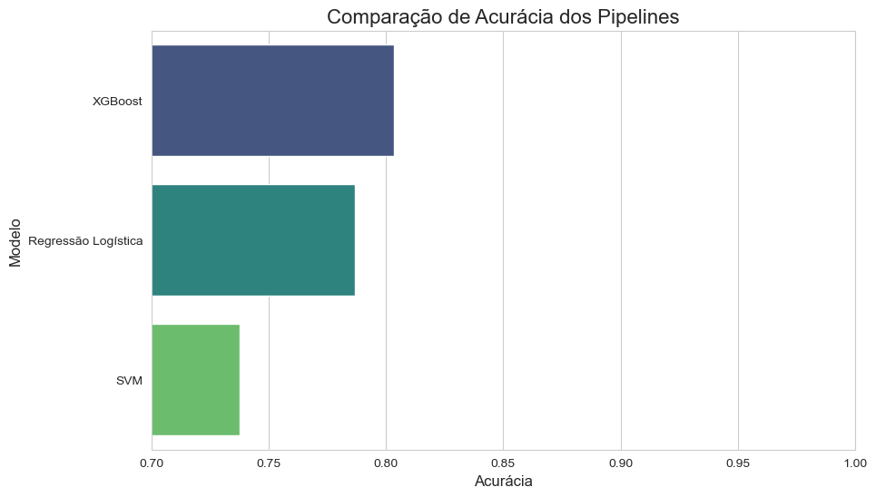

```
Ranking de Performance dos Modelos:
                Modelo  Acurácia
2              XGBoost  0.803279
0  Regressão Logística  0.786885
1                  SVM  0.737705
```

```python
# Criar um DataFrame com os resultados
results = pd.DataFrame({
    'Modelo': ['Regressão Logística', 'SVM', 'XGBoost'],
    'Acurácia': [accuracy_lr, accuracy_svm, accuracy_xgb]
})

# Ordenar os resultados
results = results.sort_values(by='Acurácia', ascending=False)

plt.figure(figsize=(10, 6))
sns.barplot(
    x='Acurácia',
    y='Modelo',
    data=results,
    palette='viridis',
    hue='Modelo',      # <<-- PASSO 1: Atribua a variável do eixo Y ao 'hue'
    legend=False       # <<-- PASSO 2: Desative a legenda redundante
)
plt.title('Comparação de Acurácia dos Pipelines', fontsize=16)
plt.xlabel('Acurácia', fontsize=12)
plt.ylabel('Modelo', fontsize=12)
plt.xlim(0.7, 1.0)
plt.show()

print("\nRanking de Performance dos Modelos:")
print(results)
```

# 4. Conclusões